# Solvent descriptors preprocessing

Simona Kolarova

# Aim

Separetly preprocess the molecular descriptors for polar solvents (PS) and non-polar solvent (NPS) by:  
- removing missing data,  
- removing descriptors of zero and near-zero variance,  
- transforming descriptors to reduce skewness,  
- centering and scalling all descriptors,  
- removing co-linear descriptors.

# Solvent descriptors

The molecular properties of each PS or NPS were described by 2702 descriptors, which were obtained from Pubchem, from Dragon, from Padel or in-house.

# Libraries

```r
library(caret)
library(e1071)
library(corrplot)
library(RColorBrewer)
```

# Datasets

Two sets of PS and NPS descriptors data were imported: one comprising descriptors for all solvents (used in predictive model training and validation) and one comprising descriptors for a reduced set of solvents (used in model training). The required preprocessing steps were determined using the latter training solvents set and applied on the former training/validation solvents set.

```r
PS_descriptors <- read.csv("Data/PS descriptors.csv")
NPS_descriptors <-read.csv("Data/NPS descriptors.csv")

PS_descriptors_training <- read.csv("Data/PS descriptors (training).csv")
NPS_descriptors_training <-read.csv("Data/NPS descriptors (training).csv")
```

# Removing descriptors containing missing data

```r
# Check whether the same number of columns containg missing data in training and training/validation dataset descriptors
if (ncol(PS_descriptors[,colSums(is.na(PS_descriptors)) != 0]) == ncol(PS_descriptors_training[,colSums(is.na(PS_descriptors_training)) != 0])) {
  print("True")
} else {
  print("False")
}
```

```
## [1] "True"
```

```r
if (ncol(NPS_descriptors[,colSums(is.na(NPS_descriptors)) != 0]) == ncol(NPS_descriptors_training[,colSums(is.na(NPS_descriptors_training)) != 0])) {
  print("True")
} else {
  print("False")
}
```

```
## [1] "True"
```

```r
# If both true, remove all variables containing a NA value
PS_descriptors <-PS_descriptors[ , colSums(is.na(PS_descriptors)) == 0]
PS_descriptors_training <- PS_descriptors_training[ , colSums(is.na(PS_descriptors_training)) == 0]
cat("Number of PS descriptors removed:", 2702-length(colnames(PS_descriptors)),"\n")
```

```
## Number of PS descriptors removed: 21
```

```r
NPS_descriptors <- NPS_descriptors[ , colSums(is.na(NPS_descriptors)) == 0]
NPS_descriptors_training <- NPS_descriptors_training[ , colSums(is.na(NPS_descriptors_training)) == 0]
cat("Number of NPS descriptors removed:", 2702-length(colnames(PS_descriptors)),"\n")
```

```
## Number of NPS descriptors removed: 21
```

# Zero and near-zero variance descriptors removal

The number of descriptors was reduced by removing all descriptors that comprise less than 2 unique values (i.e., zero variance descriptors) or 2 unique values when 1 of them is only present once (i.e., nero-zero variance descriptors).

```r
PS_descriptors_nzv<-nearZeroVar(PS_descriptors_training, freqCut = 7, uniqueCut = 23)
PS_descriptors_training<-PS_descriptors_training[-c(PS_descriptors_nzv)]
PS_descriptors<-PS_descriptors[-c(PS_descriptors_nzv)]
cat("Number of PS descriptors removed:", length(PS_descriptors_nzv),"\n")
```

```
## Number of PS descriptors removed: 2040
```

```r
NPS_descriptors_nzv<-nearZeroVar(NPS_descriptors_training, freqCut = 11, uniqueCut = 16)
NPS_descriptors_training<-NPS_descriptors_training[-c(NPS_descriptors_nzv)]
NPS_descriptors<-NPS_descriptors[-c(NPS_descriptors_nzv)]
cat("Number of NPS descriptors removed:", length(NPS_descriptors_nzv),"\n")
```

```
## Number of NPS descriptors removed: 1997
```

# Descriptors transformation, scaling and centering

First the skewness of the descriptors was estimated as:

```r
skewness_PS<-apply(PS_descriptors_training[,2:641],2,skewness)
skewness_NPS<-apply(NPS_descriptors_training[,2:684],2,skewness)
```

The results were plotted as histograms to visually access the overall level of the skewness in the solvent descriptors datasets for polar solvents and non-polar solvents.

## Polar solvent descriptors skewness

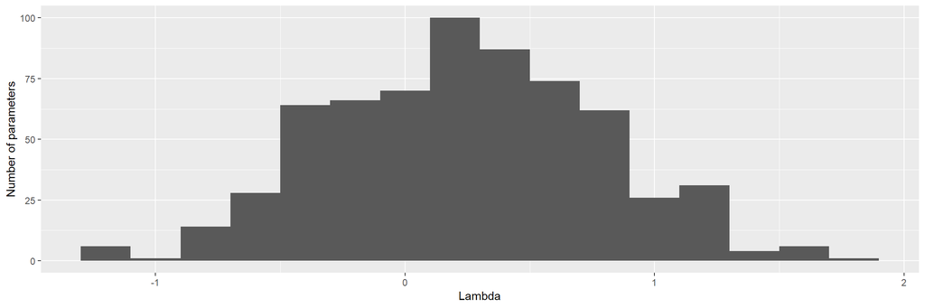

## Non-polar solvent descriptors skewness

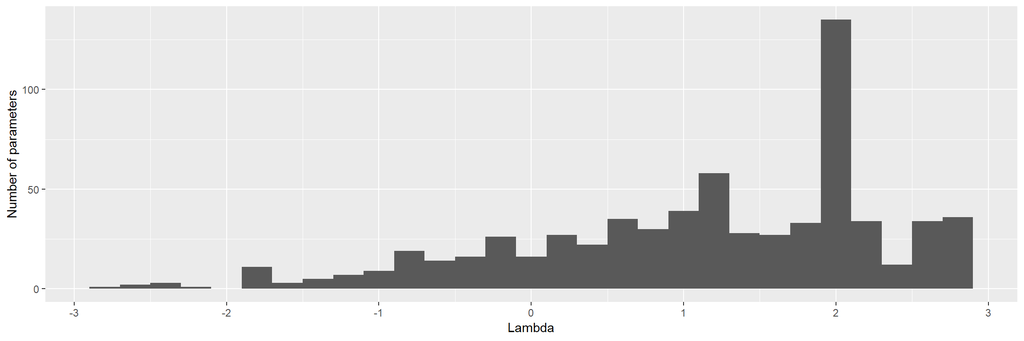

The descriptors of NPS are notably more skewed than those of PS.

To reduce the descriptors skewness the Yeo-Johnson transformation (which performs better than the alternative Box-Cox transformation at normalising variables containing zeros and negative numbers, such as the ones here) was applied to all predictors.  
Additionally, all predictors were scaled and centered, which is important for predictive model development where the best model is determined by calculating the difference between classifiers and new samples and ranking it according to scale, such as support vector machines.

## Polar solvent descriptors transormation

```
## Created from 9 samples and 640 variables
##
## Pre-processing:
##   - centered (640)
##   - ignored (0)
##   - scaled (640)
##   - Yeo-Johnson transformation (420)
##
## Lambda estimates for Yeo-Johnson transformation:
##    Min. 1st Qu.  Median    Mean 3rd Qu.    Max.
## -2.9830 -0.5054  0.4226  0.3363  1.1346  2.9800
```

## Non-polar solvent descriptors transormation

```
## Created from 13 samples and 683 variables
##
## Pre-processing:
##   - centered (683)
##   - ignored (0)
##   - scaled (683)
##   - Yeo-Johnson transformation (416)
##
## Lambda estimates for Yeo-Johnson transformation:
##    Min. 1st Qu.  Median    Mean 3rd Qu.    Max.
## -2.9623 -1.2822 -0.5927 -0.6617 -0.2935  2.9267
```

After the transformation, the overall skewness of the descriptors was significantly reduced.

## Polar solvent descriptors skewness after transoformation

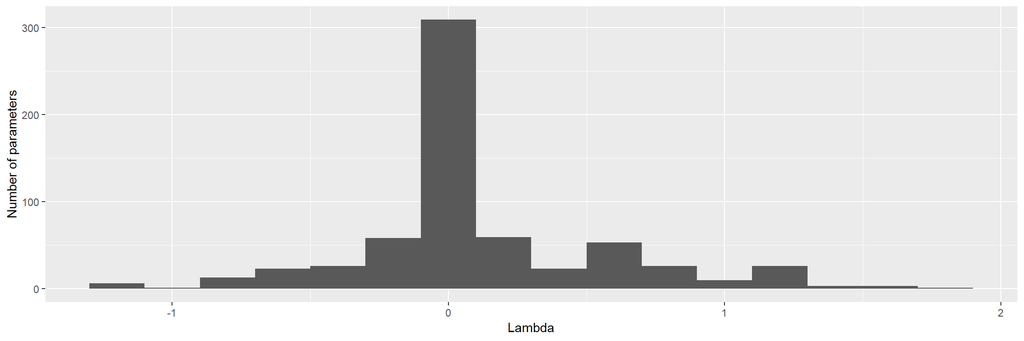

## Non-polar solvent descriptors skewness after transoformation

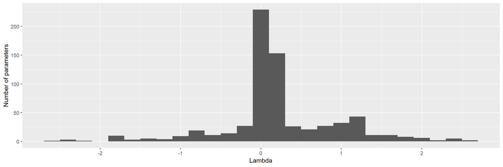

# Cross-correlation in solvent descriptors data

A number of predictive models, especially linear models (e.g., logistic regression and linear discriminant analysis), require that the predictors used are not co-linear to avoid errors in estimating the contribution (weight) of each predictor to the model.

Hence,the cross-correlation between the predictors was calculated to assess the presence of co-linearity in the predictor data set.

## Correlations between PS descriptors:

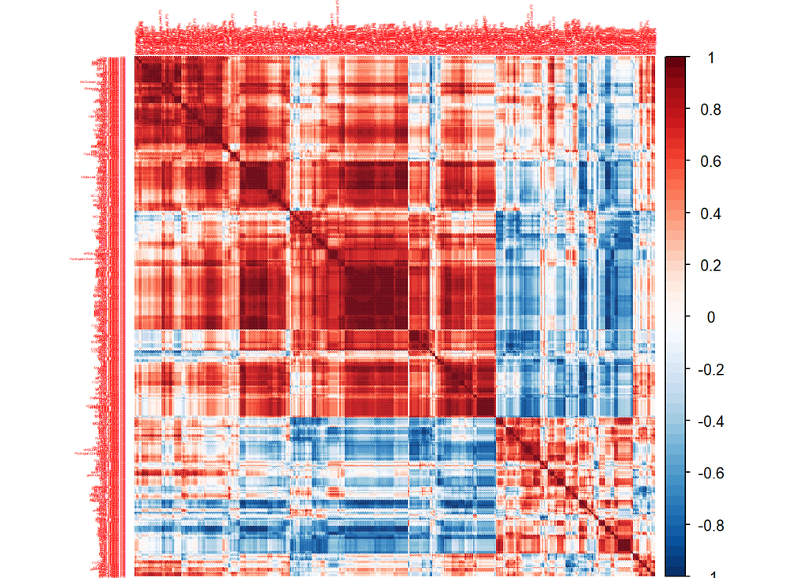

## Correlations between NPS descriptors:

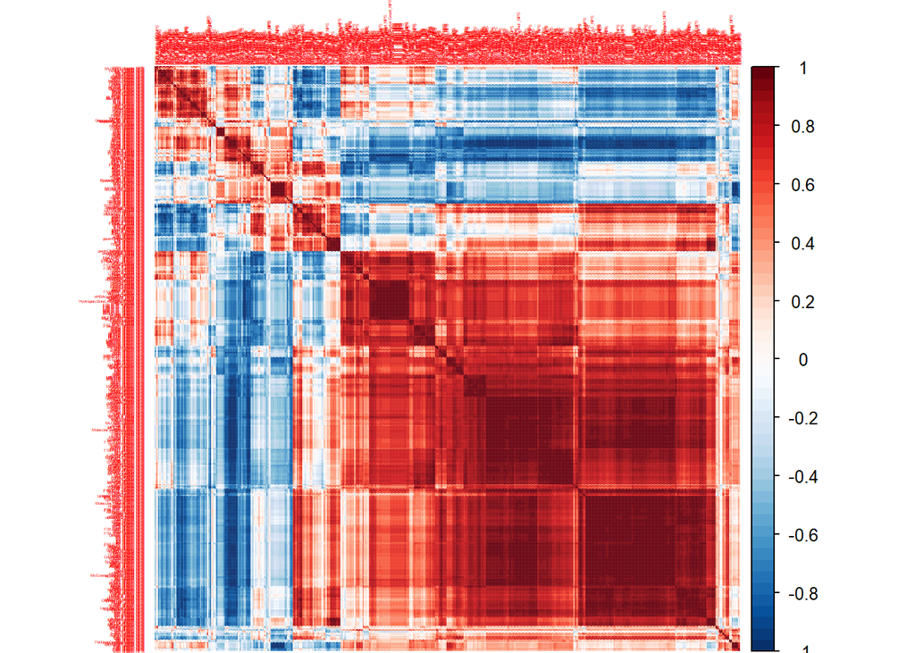

As can be seen from the two correlation plots above, there is significant co-linearity in both descriptor datasets.

# Cross-correlations reduction

To reduce this co-linearity a Pearson two-tailed correlation test was used for the polar and non-polar solvents molecular descriptors separately. A Pearson correlation of 0.735 (p=0.01, 9 polar solvents) and of 0.641 (p=0.01, 13 non-polar solvents) was considered “significant”.

## Polar solvent descriptors

First, the cross-correlations between Dragon and Padel polar solvent (PS) descriptors was reduced:

```r
PS_corr_DP <-cor(PS_descriptors_training[,8:641], method="pearson")
PS_corr_names_DP <- findCorrelation(PS_corr_DP, cutoff = 0.735, names = TRUE, exact = TRUE)

PS_colnames_DP <- colnames(PS_descriptors_training[8:641])[!(colnames(PS_descriptors_training[8:641]) %in% PS_corr_names_DP)]

cat("Number of descriptors removed:", length(PS_corr_names_DP))
```

```
## Number of descriptors removed: 602
```

Next, the cross-correlations between the reduced number of Dragon and Padel descriptors and the remaining PubChem and in-house calculated descriptors were manually removed. For this purpose, the cross-correlations between the descriptors were calculated (Pearson two-tailed correlation) and correlation values larger than 0.735 were treated as significant (assigned a “1”), while lower correlations values were treated as insignificant (assigned a “0”) .The molecular descriptors self-correlations along the matrix diagonals were also assigned a value of 0 and a binary correlation matrix was obtained. All descriptors, which were significanly correlated to the in-house and PubChem descriptors were removed.

```r
# Binary correlation matrix
PS_colnames_basic_DP <- c(colnames(PS_descriptors_training[2:7]), PS_colnames_DP)

PS_corr_basic_DP <-as.data.frame(cor(PS_descriptors_training[c(PS_colnames_basic_DP)], method="pearson"))
PS_corr_basic_DP[PS_corr_basic_DP <= abs(0.735)] <- 0
PS_corr_basic_DP[PS_corr_basic_DP > abs(0.735)] <- 1
diag(PS_corr_basic_DP) <- 0

# Removal of significantly correlated descriptors
PS_corr_basic_DP <- PS_corr_basic_DP[PS_corr_basic_DP["AmphM_PS"]== 0, PS_corr_basic_DP["AmphM_PS"] == 0]
PS_corr_basic_DP <- PS_corr_basic_DP[PS_corr_basic_DP["Hydrogen.Bond.Acceptor.Count_PS"]== 0, PS_corr_basic_DP["Hydrogen.Bond.Acceptor.Count_PS"] == 0]

cat("Number of descriptors removed:", length(PS_colnames_basic_DP)-length(colnames(PS_corr_basic_DP)),"\n")
```

```
## Number of descriptors removed: 4
```

```r
cat("Significant correlations left:", sum(PS_corr_basic_DP))
```

```
## Significant correlations left: 0
```

## Non-polar solvent descriptors

```r
NPS_corr_DP <-cor(NPS_descriptors_training[,8:684], method="pearson")
NPS_corr_names_DP <- findCorrelation(NPS_corr_DP, cutoff = 0.641, names = TRUE, exact = TRUE)

NPS_colnames_DP <- colnames(NPS_descriptors_training[8:684])[!(colnames(NPS_descriptors_training[8:684]) %in% NPS_corr_names_DP)]

cat("Number of descriptors removed:", length(NPS_corr_names_DP))
```

```
## Number of descriptors removed: 655
```

```r
# Binary correlation matrix
NPS_colnames_basic_DP <- c(colnames(NPS_descriptors_training[2:7]), NPS_colnames_DP)

NPS_corr_basic_DP <-as.data.frame(cor(NPS_descriptors_training[c(NPS_colnames_basic_DP)], method="pearson"))
NPS_corr_basic_DP[NPS_corr_basic_DP <= abs(0.735)] <- 0
NPS_corr_basic_DP[NPS_corr_basic_DP > abs(0.735)] <- 1
diag(NPS_corr_basic_DP) <- 0

# Removal of significantly correlated descriptors
NPS_corr_basic_DP <- NPS_corr_basic_DP[NPS_corr_basic_DP["Molecular.volume..A3._NPS"]== 0, NPS_corr_basic_DP["Molecular.volume..A3._NPS"] == 0]

cat("Number of descriptors removed:", length(NPS_colnames_basic_DP)-length(colnames(NPS_corr_basic_DP)),"\n")
```

```
## Number of descriptors removed: 4
```

```r
cat("Significant correlations left:", sum(NPS_corr_basic_DP))
```

```
## Significant correlations left: 0
```

# Preprocessed descriptors

34 polar solvent descriptors and 24 non-polar solvent descriptors remained after the above preprocessing steps.

## Polar solvent descriptors

```
##  [1] "Molecular.volume..A3._PS"        "XlogP3_PS"
##  [3] "Hydrogen.Bond.Donor.Count_PS"    "Hydrogen.Bond.Acceptor.Count_PS"
##  [5] "AmphM_PS"                        "J_dragon_PS"
##  [7] "MPC05_dragon_PS"                 "IDDE_dragon_PS"
##  [9] "BIC0_dragon_PS"                  "CIC3_dragon_PS"
## [11] "GGI4_dragon_PS"                  "SPAM_dragon_PS"
## [13] "MEcc_dragon_PS"                  "P2u_dragon_PS"
## [15] "E1u_dragon_PS"                   "L1v_dragon_PS"
## [17] "L3s_dragon_PS"                   "De_dragon_PS"
## [19] "Ds_dragon_PS"                    "nOHs_dragon_PS"
## [21] "C.001_dragon_PS"                 "H.052_dragon_PS"
## [23] "ALOGP2_dragon_PS"                "B03.O.O._dragon_PS"
## [25] "F01.C.C._dragon_PS"              "VC.3_padel_PS"
## [27] "ASP.4_padel_PS"                  "VE1_D_padel_PS"
## [29] "PPSA.1_padel_PS"                 "DPSA.3_padel_PS"
## [31] "FNSA.2_padel_PS"                 "WNSA.1_padel_PS"
## [33] "MOMI.XY_padel_PS"                "geomRadius_padel_PS"
```

## Non-polar solvent descriptors

```
##  [1] "Molecular.volume..A3._NPS"        "Hydrogen.Bond.Acceptor.Count_NPS"
##  [3] "AmphM_NPS"                        "X0A_dragon_NPS"
##  [5] "Yindex_dragon_NPS"                "IC2_dragon_NPS"
##  [7] "SIC3_dragon_NPS"                  "IC4_dragon_NPS"
##  [9] "DISPv_dragon_NPS"                 "L1u_dragon_NPS"
## [11] "G2u_dragon_NPS"                   "G2m_dragon_NPS"
## [13] "E2e_dragon_NPS"                   "G3s_dragon_NPS"
## [15] "E2s_dragon_NPS"                   "Dm_dragon_NPS"
## [17] "nCconj_dragon_NPS"                "C.003_dragon_NPS"
## [19] "H.052_dragon_NPS"                 "Depressant.80_dragon_NPS"
## [21] "PetitjeanNumber_padel_NPS"        "JGI8_padel_NPS"
## [23] "JGI9_padel_NPS"                   "WNSA.1_padel_NPS"
```

# Datasets

The results were used to reduce the number of predictors in the descriptor datasets.

```r
PS_colnames<-c("PS", colnames(PS_corr_basic_DP))
PS_descriptors<-PS_descriptors[c(PS_colnames)]
PS_descriptors_training<-PS_descriptors_training[c(PS_colnames)]

NPS_colnames<-c("NPS", colnames(NPS_corr_basic_DP))
NPS_descriptors<-NPS_descriptors[c(NPS_colnames)]
NPS_descriptors_training<-NPS_descriptors_training[c(NPS_colnames)]
```

# Export preprocessed datasets

```r
write.csv(PS_descriptors, "Results/PS descriptors.csv", row.names = FALSE)
write.csv(NPS_descriptors, "Results/NPS descriptors.csv", row.names = FALSE)
```